# Project 1 - Exploratory analysis by team Siddharth,Titouan and Xavier

In this project we took Several companies connected to transportation sector, whether it is aerospace Sector like Airbus Group,Dassault Aviation,Dassault Systèmes,SAFRAN and Thales , fuel/energy sector likeTotalEnergies and Gaztransport & Technigaz or car company like Peugeot and Renault.

We took subsectors within transportation sector to have a clear coorelated sets in each group

```r
library(quantmod)
tickers = c("AIR.PA", "AM.PA", "HO.PA", "SAF.PA","DSY.PA","TTE.PA","PEUG.PA","RNO.PA","ENGI.PA","GTT.PA") # or several
start_date = as.Date("2018-10-31")
end_date = as.Date("2023-10-30")
library(e1071)
library (moments)
library (ADGofTest)
library (faraway)
library(dplyr)
library(tidyr)
library(car)
library(xts)
getSymbols(na.omit(tickers, src = "yahoo", from = start_date, to = end_date))
```

```
##  [1] "AIR.PA"  "AM.PA"   "HO.PA"   "SAF.PA"  "DSY.PA"  "TTE.PA"  "PEUG.PA"
##  [8] "RNO.PA"  "ENGI.PA" "GTT.PA"
```

Now we are performing basic Statistic to find ou any shocks in the industry as a whole as well as individual companies

```
## Summary of df AIR.PA.Close :/n        .Index            .AIR.PA.Close
##  Min.   :2007-01-02    Min.   :  8.47000
##  1st Qu.:2011-03-22    1st Qu.: 22.59750
##  Median :2015-06-15    Median : 53.52000
##  Mean   :2015-06-10    Mean   : 60.13009
##  3rd Qu.:2019-09-02    3rd Qu.: 96.15500
##  Max.   :2023-11-10    Max.   :139.00000
##  NA                    NA's   :2
## [1] "mean trimmed"
## [1] 60.13009
## [1] 60.13009
## [1] "variance"
##              AIR.PA.Close
## AIR.PA.Close     1490.513
## [1] "Standard deviation"
## [1] 38.60716
##       0%      25%      50%      75%     100%
##   8.4700  22.5975  53.5200  96.1550 139.0000
## [1] "percentile"
##      5%     95%
##  12.757 125.704
## AIR.PA.Close
##     0.385958
## AIR.PA.Close
##     1.798962
## [1] 48.71082
```

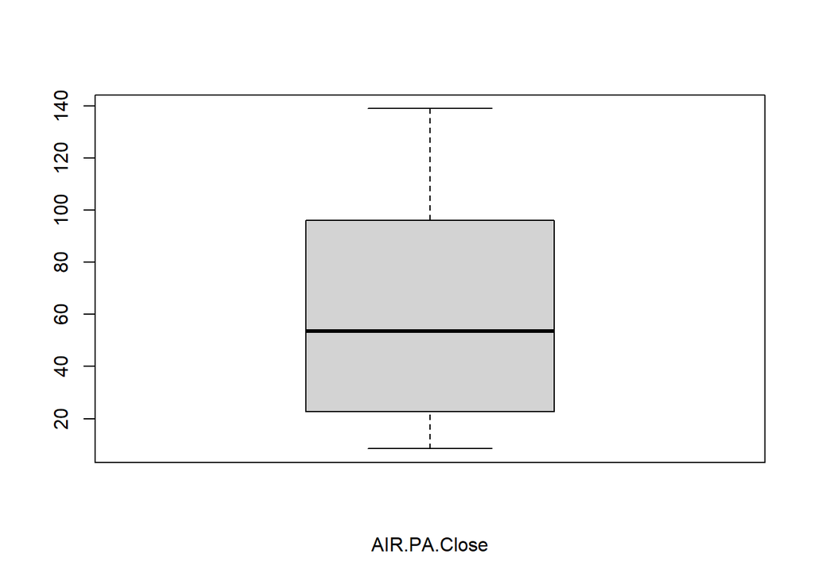

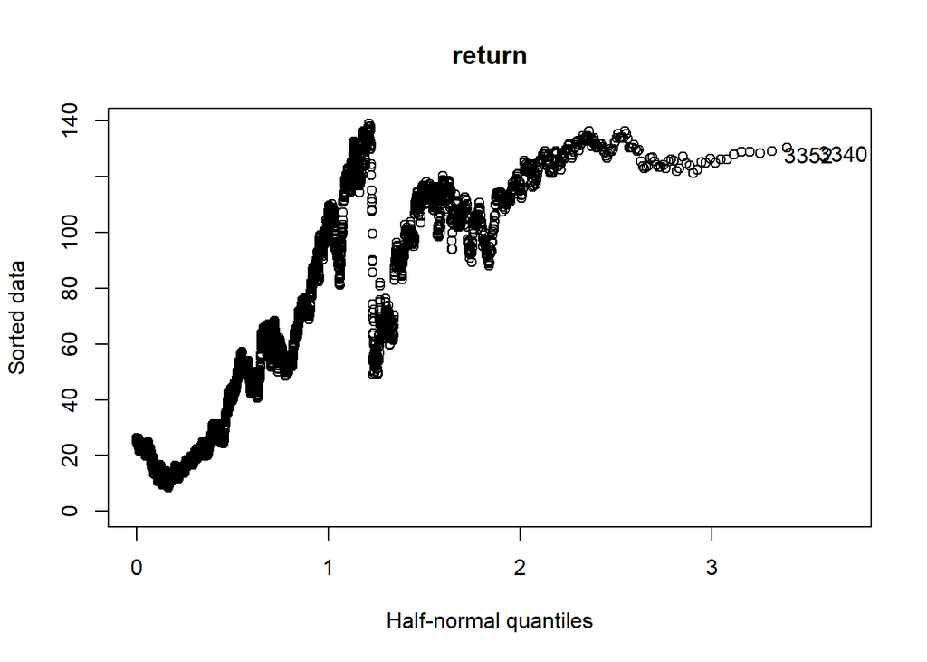

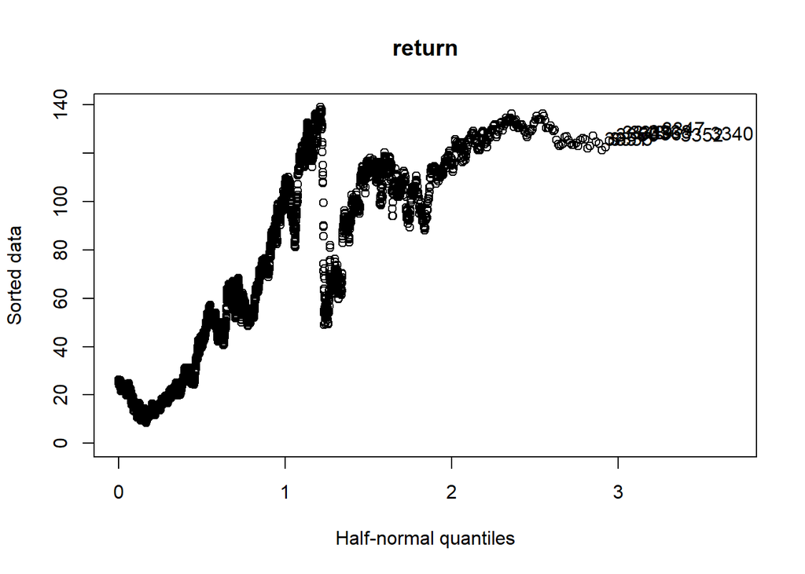

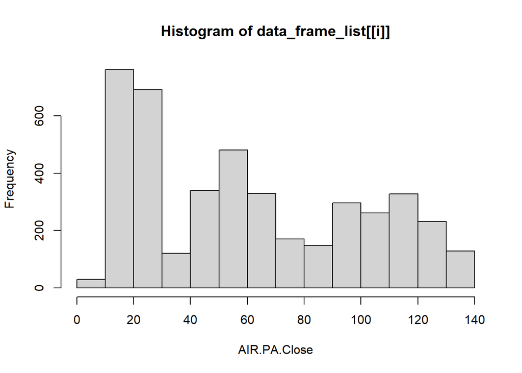

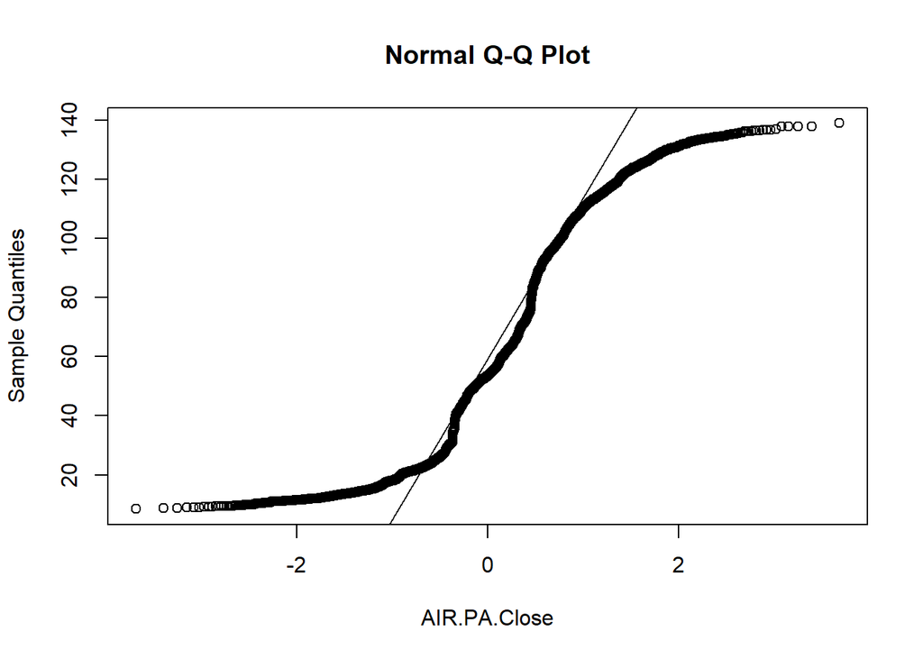

```
## Summary of df AM.PA.Close :/n        .Index             .AM.PA.Close
##  Min.   :2007-01-02    Min.   : 30.60000
##  1st Qu.:2011-03-22    1st Qu.: 68.41450
##  Median :2015-06-15    Median : 93.45000
##  Mean   :2015-06-10    Mean   : 96.93439
##  3rd Qu.:2019-09-02    3rd Qu.:122.13500
##  Max.   :2023-11-10    Max.   :190.39999
##  NA                    NA's   :2
## [1] "mean trimmed"
## [1] 96.93439
## [1] 96.93439
## [1] "variance"
##             AM.PA.Close
## AM.PA.Close    1311.648
## [1] "Standard deviation"
## [1] 36.21668
##       0%      25%      50%      75%     100%
##  30.6000  68.4145  93.4500 122.1350 190.4000
## [1] "percentile"
##       5%      95%
##  43.3961 165.3300
## AM.PA.Close
##   0.4465349
## AM.PA.Close
##    2.489608
## [1] 39.06652
```

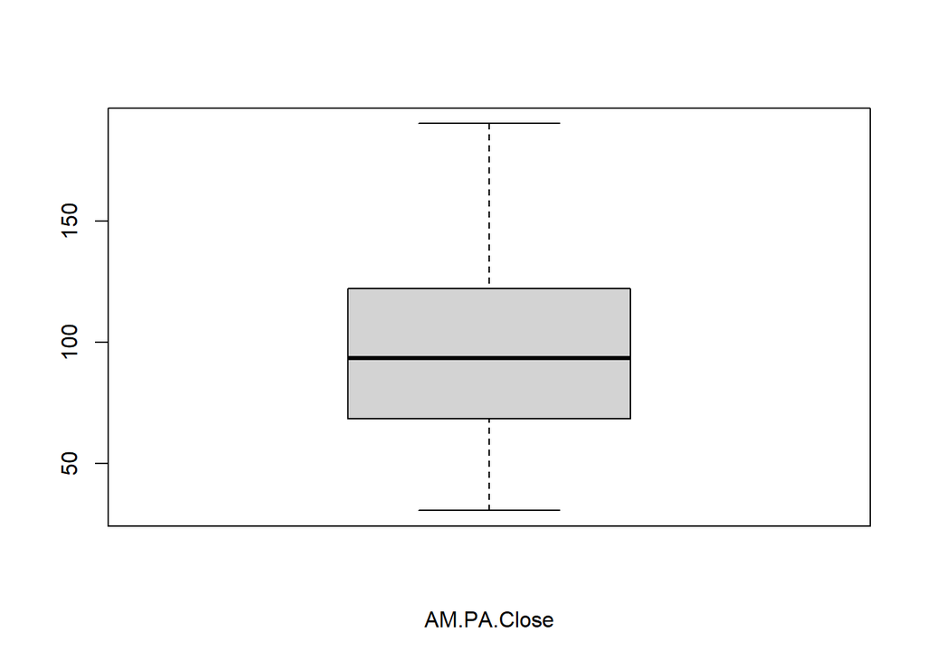

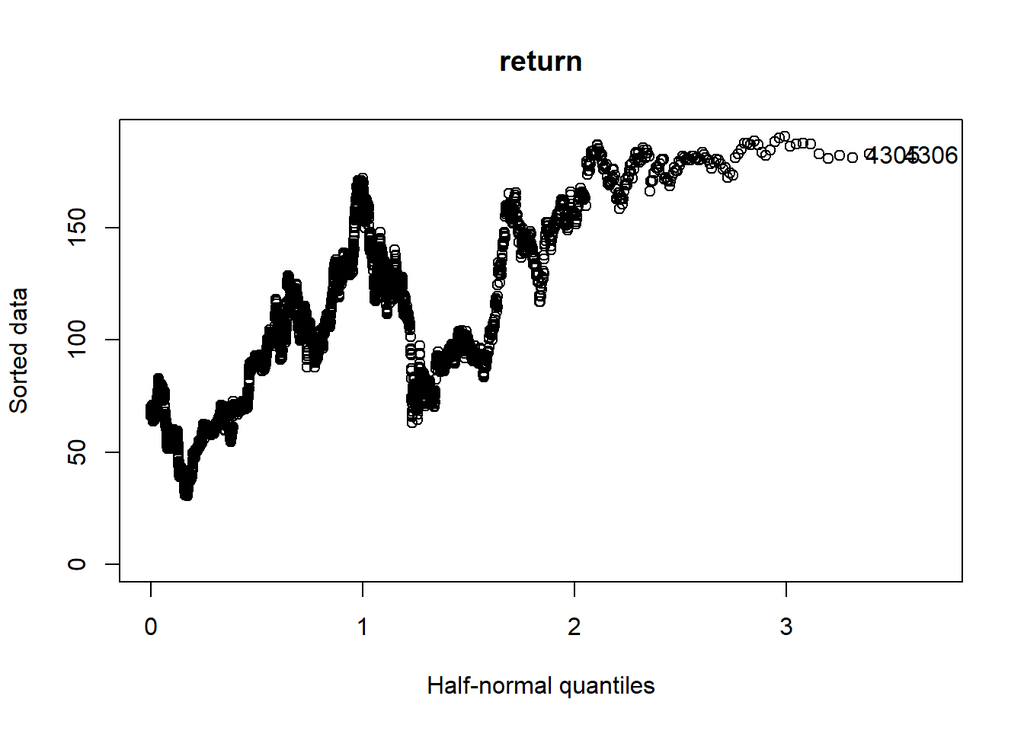

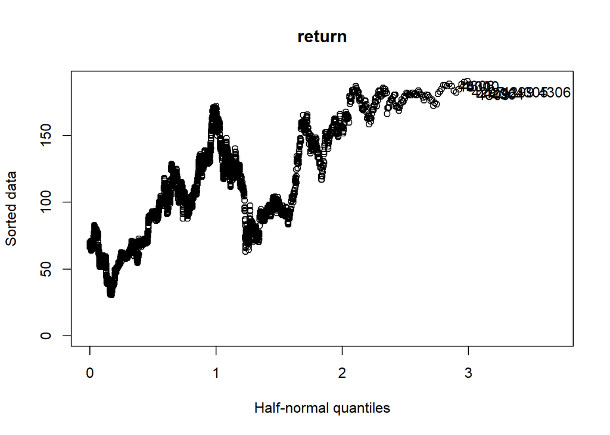

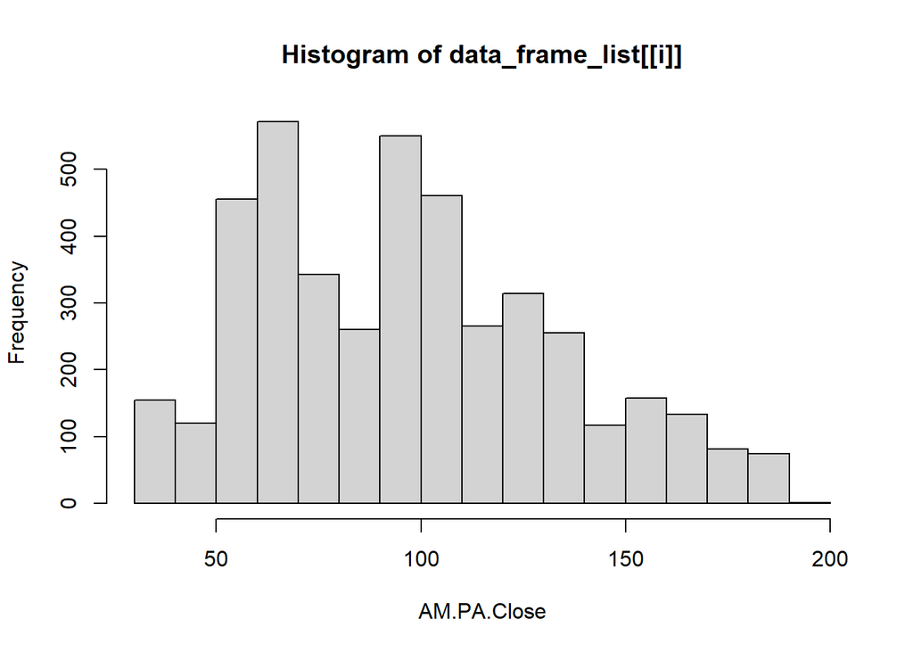

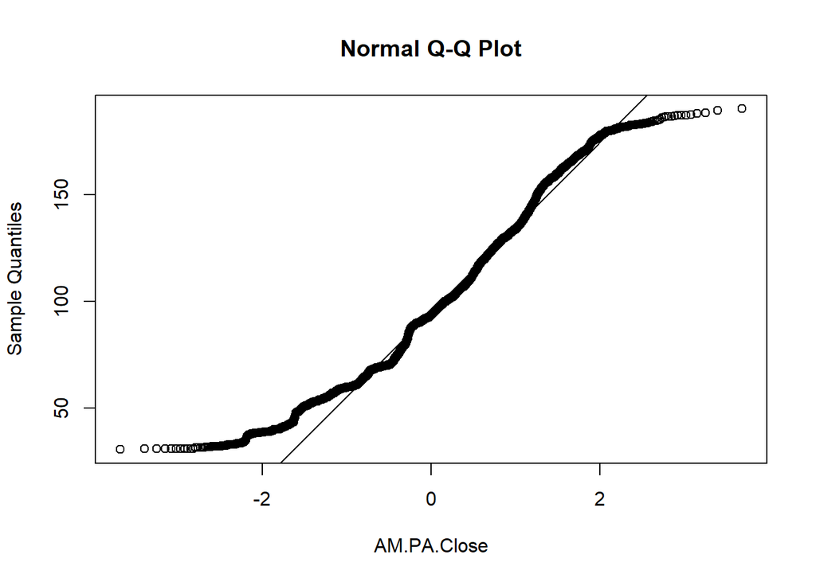

```
## Summary of df DSY.PA.Close :/n        .Index            .DSY.PA.Close
##  Min.   :2007-01-02    Min.   : 2.55100
##  1st Qu.:2011-03-22    1st Qu.: 5.52600
##  Median :2015-06-15    Median :13.08600
##  Mean   :2015-06-10    Mean   :16.91774
##  3rd Qu.:2019-09-02    3rd Qu.:27.06500
##  Max.   :2023-11-10    Max.   :56.22000
##  NA                    NA's   :2
## [1] "mean trimmed"
## [1] 16.91774
## [1] 16.91774
## [1] "variance"
##              DSY.PA.Close
## DSY.PA.Close     174.0696
## [1] "Standard deviation"
## [1] 13.19355
##     0%    25%    50%    75%   100%
##  2.551  5.526 13.086 27.065 56.220
## [1] "percentile"
##      5%     95%
##  3.4579 41.2505
## DSY.PA.Close
##    0.8458819
## DSY.PA.Close
##     2.554871
## [1] 12.8319
```

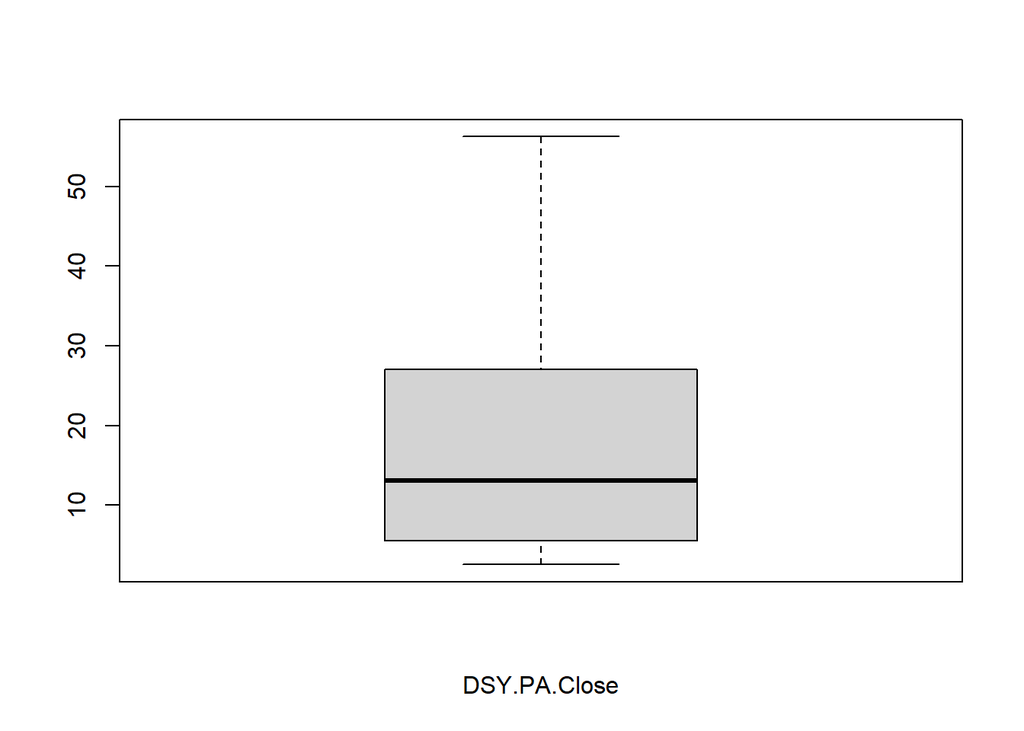

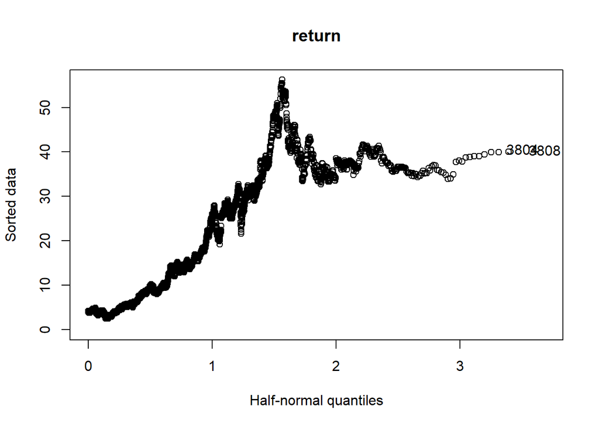

[38 more figures not shown]

```r
data_frame_list <-list(AIR.PA$AIR.PA.Close,AM.PA$AM.PA.Close,DSY.PA$DSY.PA.Close,ENGI.PA$ENGI.PA.Close,GTT.PA$GTT.PA.Close,HO.PA$HO.PA.Close,PEUG.PA$PEUG.PA.Close,RNO.PA$RNO.PA.Close,SAF.PA$SAF.PA.Close,TTE.PA$TTE.PA.Close)




for (i in 1:10) {
cat("Summary of df", paste(names(data_frame_list[[i]]), collapse= ","),":/n")
print(summary.data.frame(data_frame_list[i]))
print("mean trimmed")
print(mean(na.omit(data_frame_list[[i]], trim=0.1)))
print(mean(na.omit(data_frame_list[[i]], trim=0.2)))
print("variance")
print(var(na.omit(data_frame_list[[i]])))
print("Standard deviation")
print(sd(na.omit(data_frame_list[[i]])))
print(quantile(na.omit(data_frame_list[[i]])))
print("percentile")
print(quantile(na.omit(data_frame_list[[i]]),prob=c(0.05,0.95),na.rm=TRUE))
print(skewness(na.omit(data_frame_list[[i]])))
print(kurtosis(na.omit(data_frame_list[[i]])))
print(mad(na.omit(data_frame_list[[i]])))
boxplot(data_frame_list[[i]],horizontal=FALSE,xlab=names(data_frame_list[[i]]))$out

halfnorm(abs(data_frame_list[[i]]),main = "return", ylab ="Sorted data") # label only 2 the most outlying cases
halfnorm(abs(data_frame_list[[i]]),nlab = 10, main ="return",ylab = "Sorted data")
hist(data_frame_list[[i]],xlab =names(data_frame_list[[i]]))
qqnorm(data_frame_list[[i]],xlab =names(data_frame_list[[i]]))
qqline(data_frame_list[[i]],xlab =names(data_frame_list[[i]]))
}
```